# Test 3 Extra Credit

Jake Rozran

4/19/2021

| beer | water |
| --- | --- |
| 32 | 22 |
| 26 | 22 |
| 31 | 23 |
| 23 | 18 |
| 35 | 19 |
| 28 | 15 |
| 33 | 20 |
| 33 | 21 |
| 35 | 19 |
| 18 | 26 |
| 37 | 18 |
| 31 | 15 |
| 31 | 18 |
| 27 | 20 |
| 35 | 29 |

# Assignment:

## State the hypothesis - we want to know if drinking beer causes more mosquitoes to be attracted to you.

$H_{0}: \mu_{beer} - \mu_{water} = 0$  
$H_{A}: \mu_{beer} - \mu_{water} > 0$

## Draw a histogram of both samples - does this data come from a normal population?

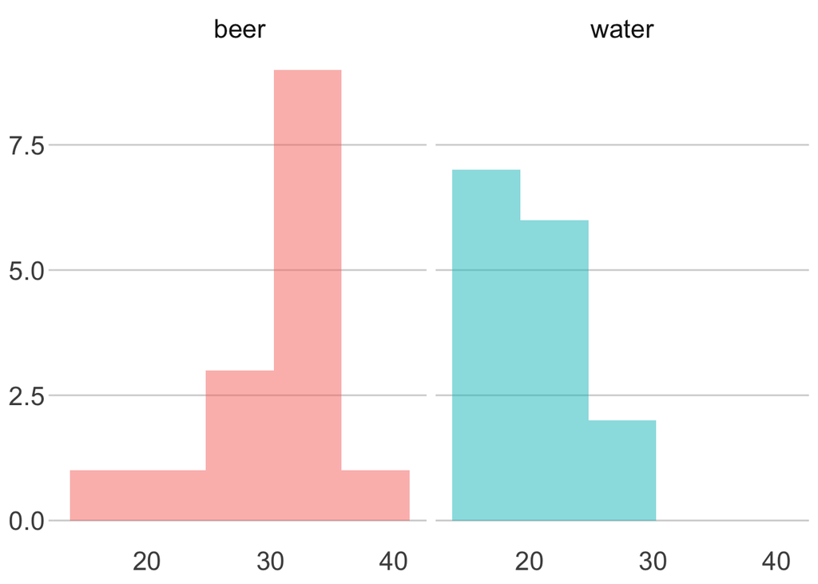

## What is the sample mean for both groups?

The sample mean for beer is: 30.33.  
The sample mean for water is: 20.33.

## How many degrees of freedom are there for each group and total?

Beer degrees of freedom: 14  
Water degrees of freedom: 14  
Total degrees of freedom: 28

## What is the sample standard deviation for both groups?

Beer standard deviation: 5.14  
Water standard deviation: 3.75

## What is the pooled variance for this experiment?

$s_{p}^{2} = \frac{df_{beer}s_{beer}^{2} + df_{water}s_{water}^{2}} {df_{beer} + df_{water}}$

The pooled variance is: 20.24

## What is the standard error for this experiment?

$SE_{\overline{Y}_{beer}-\overline{Y}_{water}} = \sqrt{s_{p}^{2}(\frac{1}{n_{beer}}+\frac{1}{n_{water}})}$

The standard error is: 1.64

## What is the t-statistic for this experiment?

$t = \frac{\overline{Y}_{beer} - \overline{Y}_{wter}} {SE_{\overline{Y}_{beer}-\overline{Y}_{wter}}}$

The t-statistic is: 6.09

## What is the critical value of t for this experiment?

The critical value for this experiment is: 1.7

## What is our conclusion?

Our t-statistic is much more extreme than our critical value, thus we can reject the null hypothesis; we have significant evidence that the beer drinking group attracts more mosquitos than those who drink water.